# Chapter 1 exercises for Statistical Computing with R by Rizzo

Kyoko

2026-04-28

```r
library(tidyverse)
```

# 1.1

**Generate a random sample x1, . . . , x100 of data from the $t_4$ (df=4) distribution using the rt function. Use the MASS::truehist function to display a probability histogram of the sample.**

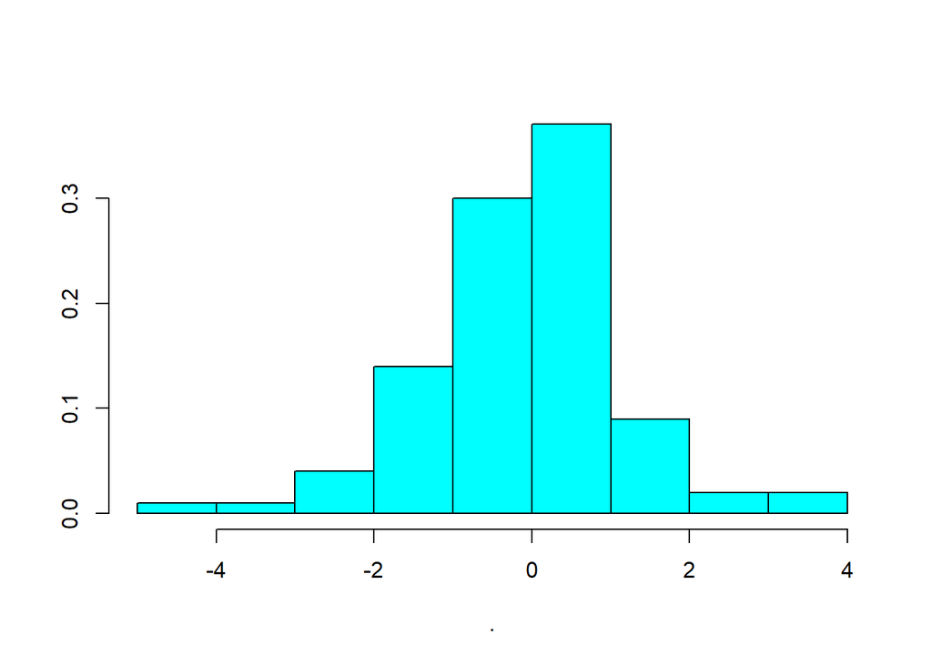

```r
# ncp not specified uses the central t distribution
rt(n = 100, df = 4) %>% MASS::truehist()
```

# 1.2

**Add the t4 density curve (dt) to your histogram in Exercise 1.1 using the curve function with add=TRUE.**

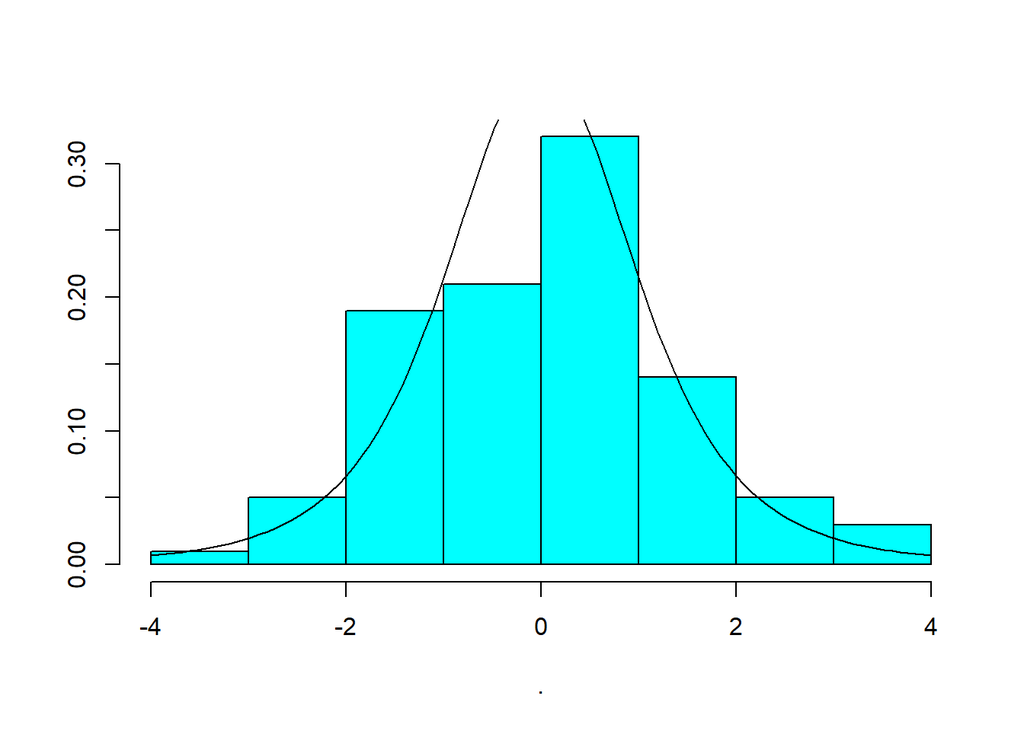

```r
rt(n = 100, df = 4) %>% MASS::truehist()
curve(dt(x,  df=4), add=TRUE)
```

# 1.3

**Add an estimated density curve to your histogram in Exercise 1.2 using density. For example, lines(density(x), col=2) will add the density estimate using the color red. Notice that the density estimate (density) is an approximation to the density of the sampled distribution (in this case the t4 density). (Density estimation and the density function are covered in detail in Chapter 12.)**

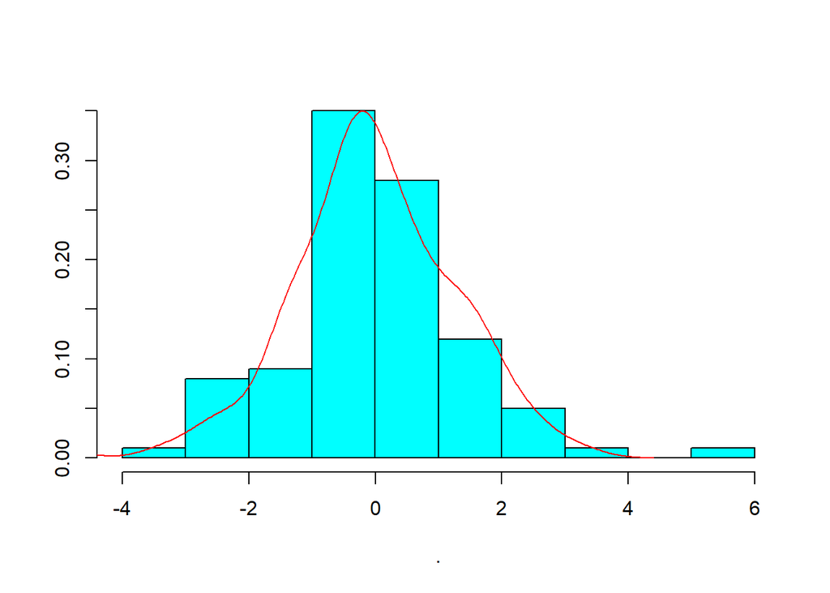

```r
rt(n = 100, df = 4) %>% MASS::truehist()
lines(density(rt(n = 100, df = 4) ), col="red")
```

# 1.4

## a.

**Write an R function f in R to implement the function f(x) = (x − a)/b that will transform an input vector x and return the result. The function should take three input arguments: x, a, b.**

```r
f = function(x, a, b){
  y = (x-a)/b
  return(y)
}
```

## b.

**To transform x to the interval [0, 1] we subtract the minimum value and divide by the range: y <- f(x, a = min(x), b = max(x) - min(x)) Generate a random sample of Normal(mu = 2, sigma = 2) data using rnorm and use your function f to transform this sample to the interval [0, 1]. Print a summary of both the sample x and the transformed sample y to check the result.**

```r
set.seed(123)
myrand = rnorm(n=100, mean=2, sd =2)
```

```r
f_interval = function(x){
  a=min(x)
  b=max(x) - min(x)
  y=(x-a)/b
  return(y)
}
```

```r
summary(myrand)
```

```
##    Min. 1st Qu.  Median    Mean 3rd Qu.    Max.
##  -2.618   1.012   2.124   2.181   3.384   6.375
```

```r
summary(f_interval(myrand))
```

```
##    Min. 1st Qu.  Median    Mean 3rd Qu.    Max.
##  0.0000  0.4037  0.5273  0.5337  0.6674  1.0000
```

# 1.5

**Refer to Exercise 1.4. Suppose that we want to transform the x sample so that it has mean zero and standard deviation one (studentize the sample). That is, we want**

$$z_i = \frac{(x_i - \bar{x})}{s} ,
i=1,...,n$$

**where s is the standard deviation of the sample. Using your function f this is z <- f(x, a = mean(x), b = sd(x)). Display a summary and histogram of the studentized sample z. It should be centered exactly at zero. Use sd(z) to check that the studentized sample has standard deviation exactly 1.0.**

```r
f_studentize = function(x){
  a=mean(x)
  b=sd(x)

  zed = (x - a)/b
  return(zed)
}
```

```r
f_studentize(myrand) %>% summary()
```

```
##     Min.  1st Qu.   Median     Mean  3rd Qu.     Max.
## -2.62876 -0.64006 -0.03139  0.00000  0.65885  2.29721
```

```r
f_studentize(myrand) %>% sd()
```

```
## [1] 1
```

# 1.6

**Using your function f of Exercise 1.4, center and scale your Normal(mu = 2, sd = 2) sample by subtracting the sample median and dividing by the sample interquartile range (IQR). Compare your results to Exercise 1.5.**

```r
f_center_scale = function(x){
  a= median(x)
  b=IQR(x)

  y = (x - a)/b
  return(y)
}
```

```r
f_center_scale(myrand) %>% summary()
```

```
##     Min.  1st Qu.   Median     Mean  3rd Qu.     Max.
## -1.99964 -0.46860  0.00000  0.02416  0.53140  1.79272
```

It is now centered at the median instead of the mean.

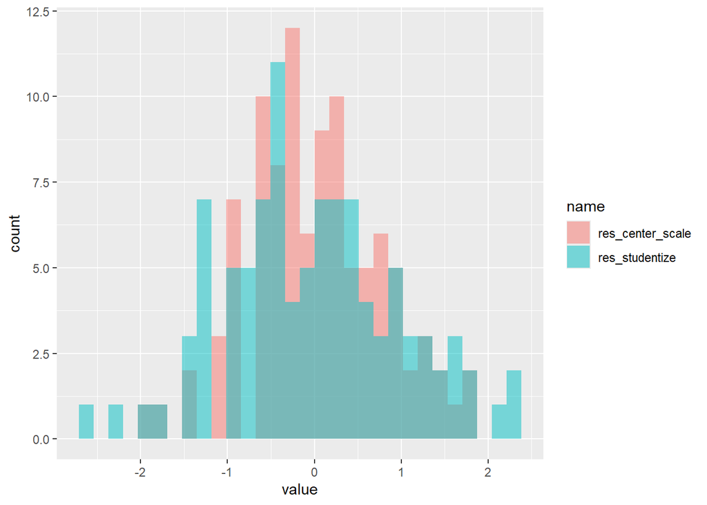

```r
mydf = data.frame(
  res_studentize = f_studentize(myrand),
  res_center_scale = f_center_scale(myrand)
) %>%
  mutate(index = seq(1:nrow(.))) %>%
  pivot_longer(cols = c("res_studentize", "res_center_scale"))


ggplot(mydf, aes(x= value,  fill=name)) +
  geom_histogram(position="identity", alpha = 0.5, bins=30)
```

# 1.7

**(ggplot) Refer to Example 1.14 where we displayed an array of scatterplots using ggplot with facet_wrap. One of the variables in the mpg data is drv, a character vector indicating whether the vehicle is frontwheel drive, rear-wheel drive, or four-wheel drive. Add color = drv in aes: aes(displ, hwy, color = drv) and display the revised plot. Your scatterplots should now have the three levels of drv coded by color and the plot should have automatically generated a legend for drv color.**

```r
summary(mpg)
```

```
##  manufacturer          model               displ            year
##  Length:234         Length:234         Min.   :1.600   Min.   :1999
##  Class :character   Class :character   1st Qu.:2.400   1st Qu.:1999
##  Mode  :character   Mode  :character   Median :3.300   Median :2004
##                                        Mean   :3.472   Mean   :2004
##                                        3rd Qu.:4.600   3rd Qu.:2008
##                                        Max.   :7.000   Max.   :2008
##       cyl           trans               drv                 cty
##  Min.   :4.000   Length:234         Length:234         Min.   : 9.00
##  1st Qu.:4.000   Class :character   Class :character   1st Qu.:14.00
##  Median :6.000   Mode  :character   Mode  :character   Median :17.00
##  Mean   :5.889                                         Mean   :16.86
##  3rd Qu.:8.000                                         3rd Qu.:19.00
##  Max.   :8.000                                         Max.   :35.00
##       hwy             fl               class
##  Min.   :12.00   Length:234         Length:234
##  1st Qu.:18.00   Class :character   Class :character
##  Median :24.00   Mode  :character   Mode  :character
##  Mean   :23.44
##  3rd Qu.:27.00
##  Max.   :44.00
```

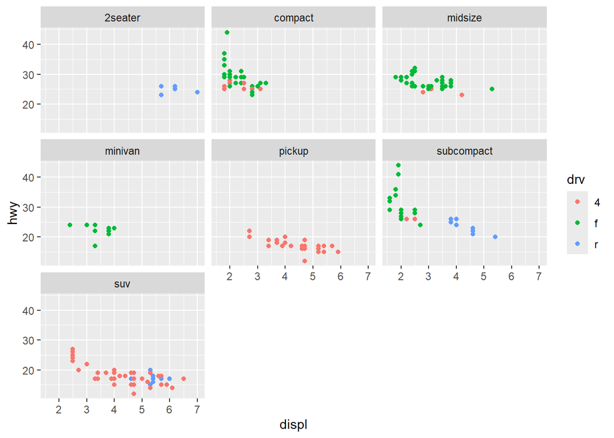

```r
ggplot(mpg, aes(displ, hwy, color = drv)) +
geom_point() +
facet_wrap(~ class)
```

# 1.8

**(RStudio and knitr) This exercise is intended to serve as an introduction to report writing with R Markdown. Install the knitr package if it is not installed. Create an html report using R Markdown and knitr in RStudio. The report should include the code and output of Examples 1.12 and 1.14 with appropriate headings and a brief explanation of each example.**